# Final_Project

ziqi xuan

## Introduction

#### About Tesla

- Tesla is an innovative American company known for producing electric vehicles and clean energy solutions. Founded in 2003 by Elon Musk and others, Tesla aims to accelerate the world’s transition to sustainable energy through electric cars and renewable energy products. It also produces solar panels and solar roofs.

#### Purpose of the project

- The purpose of this project is to develop a model that will predict the value for the Tesla used car. I choose Tesla simply because I like their car, looks very sci-fi.

#### Data Citation

-The dataset used in this study originates from Kaggle, a platform for predictive modelling and analytics competitions. It consists of information related to used Tesla vehicles, encompassing a variety of features such as model, odometer reading, price, drive train configuration, driver assistance system (DAS) features, accident history, paint job, wheel type, interior type, and geographical region. This dataset provides a comprehensive overview of the attributes that can influence the resale value of Tesla cars, making it a valuable resource for conducting exploratory data analysis, predictive modelling, and insights generation in the context of used electric vehicle markets.

-Formal Citation: Raj Palepu, Aravind. (2021). Tesla Used Cars Dataset. Retrieved from https://www.kaggle.com/datasets/aravindrajpalepu/tesla-used-cars.

#### Column name description

- model : Car Model Name
- year : Car Model Release Year
- odometer : Mileage
- price : Price of the Car
- location : Listing Location
- driveTrain : AWD or RWD
- DAS : Autopilot Type, it is a automatically driving system
- accident_history : Accident History
- paintJob : Paint Job type
- wheels : Wheel specs
- emi : Equated Monthly Installment
- zipCode : Zip Code
- interior : Type of Interior
- state : State

## Exploratory Data Analysis

#### Loading packages, exploring and tidying data

```r
library(tidymodels)
library(ISLR)
library(ISLR2)
library(tidyverse)
library(glmnet)
library(modeldata)
library(ggthemes)
library(janitor)
library(naniar)
library(corrplot)
library(patchwork)
library(rpart.plot)
library(ranger)
library(vip)
library(visdat)
library(dials)
library(kknn)

tidymodels_prefer()

set.seed(131214)
```

```r
# loading the data
data <- read.csv("tslaUsedCarsInventoryDataSet.csv")

# cleaning the column names
data <- clean_names(data)

# check first few lines of data
head(data)
```

```
##     model year odometer price       location                     drive_train
## 1 Model S 2018    36438 53300      Colma, CA 100D Long Range All-Wheel Drive
## 2 Model S 2018    30180 59200      Colma, CA 100D Long Range All-Wheel Drive
## 3 Model S 2018    95696 36100 Scottsdale, AZ 100D Long Range All-Wheel Drive
## 4 Model S 2018    36438 53300      Colma, CA 100D Long Range All-Wheel Drive
## 5 Model S 2018    30180 59200      Colma, CA 100D Long Range All-Wheel Drive
## 6 Model S 2018    95696 36100 Scottsdale, AZ 100D Long Range All-Wheel Drive
##                   das                  accident_history
## 1           Autopilot               Previously Repaired
## 2 Previously Repaired 30-Day Premium Connectivity Trial
## 3  Enhanced Autopilot      No Reported Accidents/Damage
## 4           Autopilot               Previously Repaired
## 5 Previously Repaired 30-Day Premium Connectivity Trial
## 6  Enhanced Autopilot      No Reported Accidents/Damage
##                        paint_job                               wheels      emi
## 1           Red Multi-Coat Paint         19" Silver Slipstream Wheels $824 /mo
## 2 Midnight Silver Metallic Paint 21" Sonic Carbon Twin Turbine Wheels $930 /mo
## 3 Midnight Silver Metallic Paint   19" Sonic Carbon Slipstream Wheels $514 /mo
## 4           Red Multi-Coat Paint         19" Silver Slipstream Wheels $824 /mo
## 5 Midnight Silver Metallic Paint 21" Sonic Carbon Twin Turbine Wheels $930 /mo
## 6 Midnight Silver Metallic Paint   19" Sonic Carbon Slipstream Wheels $514 /mo
##   zip_code               interior state
## 1    85209 Cream Premium Interior    CA
## 2    85209 Black Premium Interior    CA
## 3    85209 Black Premium Interior    AZ
## 4    85251 Cream Premium Interior    CA
## 5    85251 Black Premium Interior    CA
## 6    85251 Black Premium Interior    AZ
```

- As I checked the first few rows, I already found there are some problems. The ‘das’ variable means autopilot type and it only has three different types which are: Autopilot, Enhanced Autopilot, and Full Self-Driving Capability. But in the second and fifth lines, the variable ‘das’ is written as previously repaired. And this should appear in accident_history. So lets check how many previously repaired are in ‘das’ variable.
- Also in ‘accident_history’, there is a wrong value called 0-Day Premium Connectivity Trial.

```r
# checking 'das' variable
# unique values in 'das' variable
unique(data$das)
```

```
## [1] "Autopilot"                    "Previously Repaired"
## [3] "Enhanced Autopilot"           "Full Self-Driving Capability"
```

```r
excluded_values <- c("Autopilot", "Enhanced Autopilot", "Full Self-Driving Capability")

result <- data %>%
  filter(!(das %in% excluded_values)) %>%
  group_by(das) %>%
  summarise(count = n())

# viewing the result
print(result)
```

```
## # A tibble: 1 × 2
##   das                 count
##   <chr>               <int>
## 1 Previously Repaired     5
```

```r
# checking 'accident_history' variable
unique(data$accident_history)
```

```
## [1] "Previously Repaired"               "30-Day Premium Connectivity Trial"
## [3] "No Reported Accidents/Damage"
```

```r
excluded_acc_values <- c("Previously Repaired", "No Reported Accidents/Damage")

acc_result <- data %>%
  filter(!(accident_history %in% excluded_acc_values)) %>%
  group_by(accident_history) %>%
  summarise(count = n())

print(acc_result)
```

```
## # A tibble: 1 × 2
##   accident_history                  count
##   <chr>                             <int>
## 1 30-Day Premium Connectivity Trial     5
```

- For ‘das’ variable: We can see that except three correct type, there is only one different type in ‘das’ variable which is previously repaired. Since there are only 5 observation wrong in 1912 observations. I will just delete those 5 rows.
- For ‘accident_history’ : it is same as ‘das’ variable, only 5 mistake, so I will delete them.

```r
values_to_remove_das <- c("Previously Repaired")
values_to_remove_acc <- c("30-Day Premium Connectivity Trial")


data <- data %>%
  filter(!(data$das %in% values_to_remove_das))

data <- data %>%
  filter(!(data$accident_history %in% values_to_remove_acc))

head(data)
```

```
##     model year odometer price       location                     drive_train
## 1 Model S 2018    36438 53300      Colma, CA 100D Long Range All-Wheel Drive
## 2 Model S 2018    95696 36100 Scottsdale, AZ 100D Long Range All-Wheel Drive
## 3 Model S 2018    36438 53300      Colma, CA 100D Long Range All-Wheel Drive
## 4 Model S 2018    95696 36100 Scottsdale, AZ 100D Long Range All-Wheel Drive
## 5 Model S 2018    95696 36100 Scottsdale, AZ 100D Long Range All-Wheel Drive
## 6 Model S 2018    95696 36100 Scottsdale, AZ 100D Long Range All-Wheel Drive
##                  das             accident_history
## 1          Autopilot          Previously Repaired
## 2 Enhanced Autopilot No Reported Accidents/Damage
## 3          Autopilot          Previously Repaired
## 4 Enhanced Autopilot No Reported Accidents/Damage
## 5 Enhanced Autopilot No Reported Accidents/Damage
## 6 Enhanced Autopilot No Reported Accidents/Damage
##                        paint_job                             wheels      emi
## 1           Red Multi-Coat Paint       19" Silver Slipstream Wheels $824 /mo
## 2 Midnight Silver Metallic Paint 19" Sonic Carbon Slipstream Wheels $514 /mo
## 3           Red Multi-Coat Paint       19" Silver Slipstream Wheels $824 /mo
## 4 Midnight Silver Metallic Paint 19" Sonic Carbon Slipstream Wheels $514 /mo
## 5 Midnight Silver Metallic Paint 19" Sonic Carbon Slipstream Wheels $514 /mo
## 6 Midnight Silver Metallic Paint 19" Sonic Carbon Slipstream Wheels $514 /mo
##   zip_code               interior state
## 1    85209 Cream Premium Interior    CA
## 2    85209 Black Premium Interior    AZ
## 3    85251 Cream Premium Interior    CA
## 4    85251 Black Premium Interior    AZ
## 5    85254 Black Premium Interior    AZ
## 6    85260 Black Premium Interior    AZ
```

#### Checking missingness and dropping unwanted variable

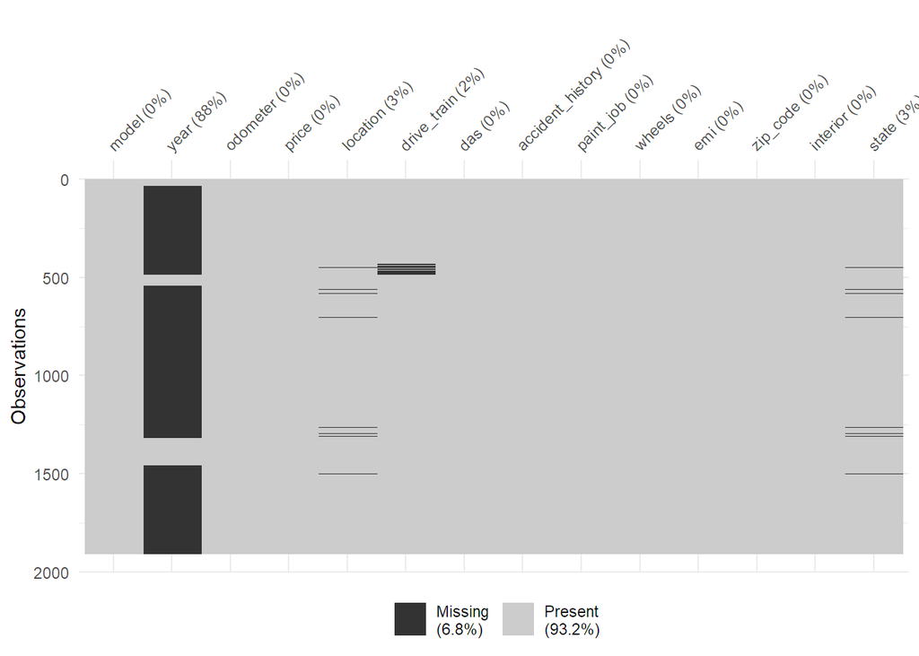

```r
data[data == ""] <- NA
vis_miss(data)
```

- Since there’s too many missing observations for year, I will drop the entire ‘year’ column.
- The ‘location’ contains the information for zip_code and state. I will keep state and delete location and zip_code since state is enough for me.
- Also the emi is calculated from price which will be highly correlated. So we need to remove this variable.
- I will also drop those rows with missing value since they are only few.

```r
# removing location and zip_code
data <- data %>%
  select(-location, -zip_code, -year, -emi)

# droping the rows with missing value
data <- drop_na(data)
```

#### Checking correlation and distribution

##### Checking price and odometer

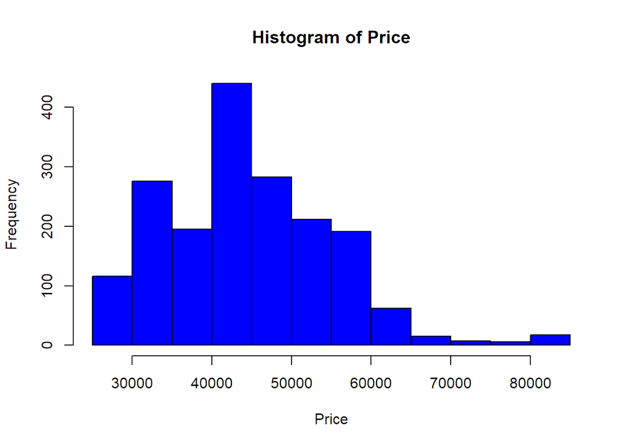

```r
hist(data$price, main = "Histogram of Price", xlab = "Price", col = "blue")
```

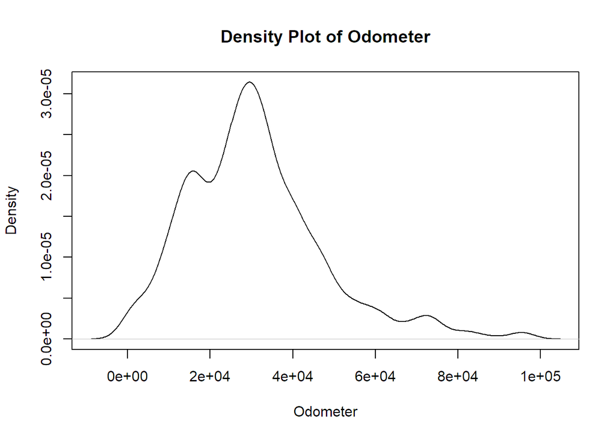

```r
# Density plot for the odometer variable
plot(density(data$odometer), main = "Density Plot of Odometer", xlab = "Odometer")
```

- The histogram of price shows a right-skewed distribution, indicating that most of the Tesla used cars are priced in the middle range, with fewer cars priced very high.
- The density map of the odometer also shows that most odometers are in the middle range, because Tesla’s cheaper models are all introduced in the past 8 years, so people are not driving too much yet.

##### Checking categorical variable

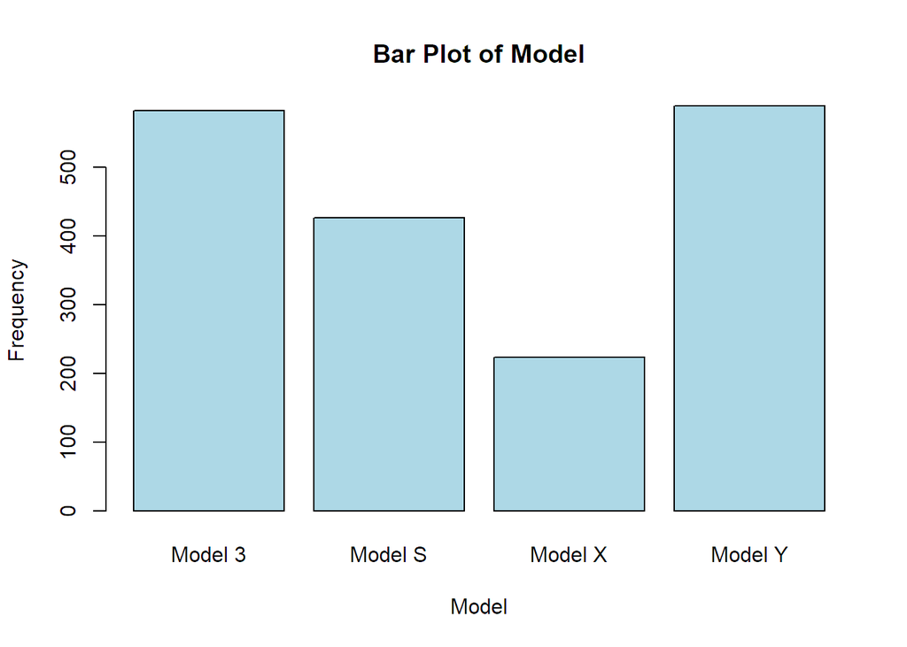

```r
# Bar plot for the model variable
barplot(table(data$model), main = "Bar Plot of Model", xlab = "Model", ylab = "Frequency", col = "lightblue")
```

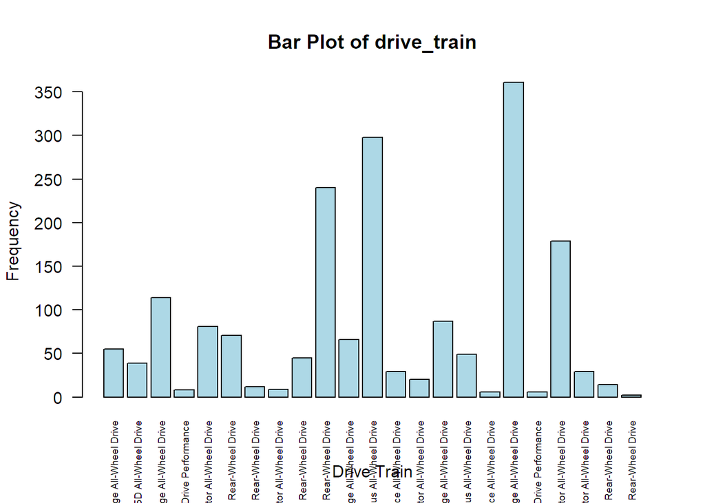

```r
# Bar plot for the drive_train variable
barplot(table(data$drive_train),
        las = 2,
        cex.names = 0.6,
        xlab = "Drive Train",
        ylab = "Frequency",
        main = "Bar Plot of drive_train",
        col = "lightblue")
```

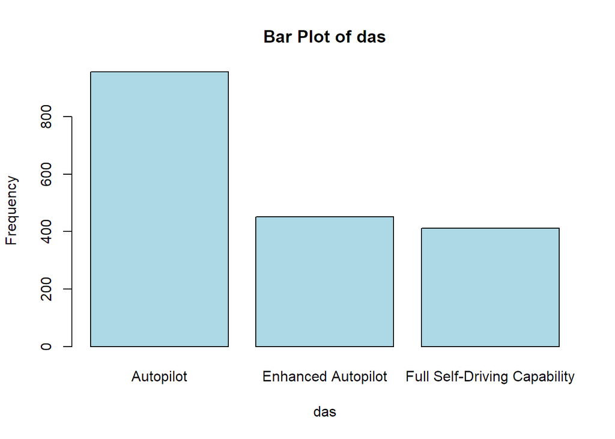

```r
# Bar plot for the das variable
barplot(table(data$das), main = "Bar Plot of das", xlab = "das", ylab = "Frequency", col = "lightblue")
```

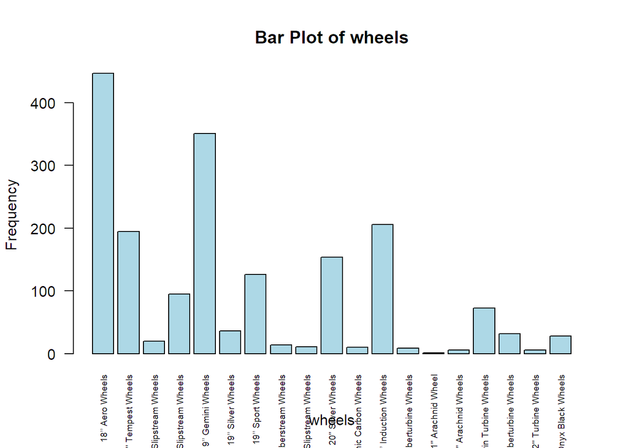

```r
# Bar plot for the wheels variable
barplot(table(data$wheels),
        las = 2,
        cex.names = 0.6,
        xlab = "wheels",
        ylab = "Frequency",
        main = "Bar Plot of wheels",
        col = "lightblue")
```

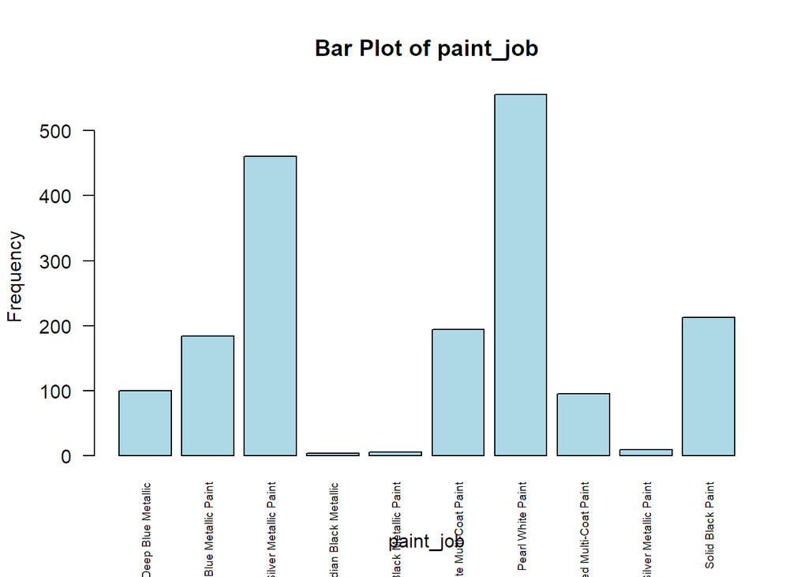

```r
# Bar plot for the paint_job variable
barplot(table(data$paint_job),
        las = 2,
        cex.names = 0.6,
        xlab = "paint_job",
        ylab = "Frequency",
        main = "Bar Plot of paint_job",
        col = "lightblue")
```

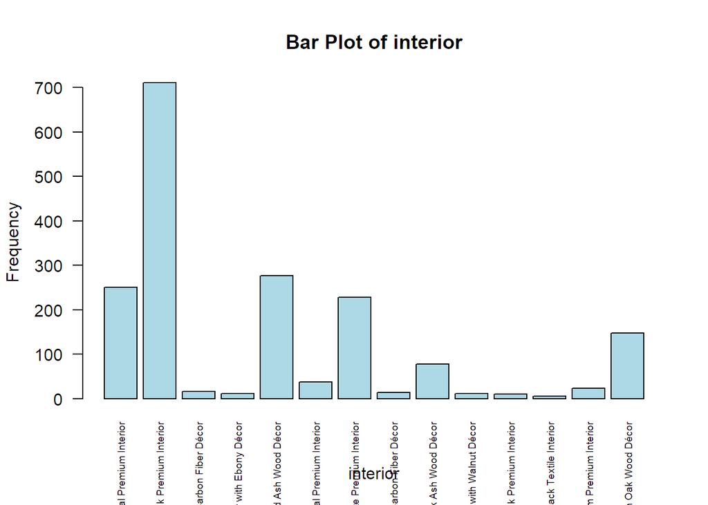

```r
# Bar plot for the interior variable
barplot(table(data$interior),
        las = 2,
        cex.names = 0.6,
        xlab = "interior",
        ylab = "Frequency",
        main = "Bar Plot of interior",
        col = "lightblue")
```

#### Tidying the data

- Except what i already said, I will also convert the state into west, midwest, northeast and south.

```r
# tidying 'drive_train' variable
data$drive_train<- ifelse(grepl("All-Wheel", data$drive_train) & grepl("Performance", data$drive_train),
                                    "All-wheel performance",
                                    ifelse(grepl("All-Wheel", data$drive_train),
                                           "All-wheel drive",
                                           ifelse(grepl("Rear-Wheel", data$drive_train),
                                                  "Rear-wheel drive",
                                                  "Other")))
# tidying 'state variable
data <- data %>%
  mutate(region = forcats::fct_collapse(state,
                                        west = c("CA", "OR", "WA", "ID",
                                                 "MT", "NV", "WY", "UT",
                                                 "CO", "AZ", "NM", "AK",
                                                 "HI"),
                                        midwest = c("ND", "SD", "NE", "KS",
                                                    "MN", "IA", "MO", "WI",
                                                    "IL", "MI", "IN", "OH"),
                                        northeast = c("ME", "VT", "NH", "MA",
                                                      "CT", "RI", "NY", "PA",
                                                      "NJ"),
                                        south = c("TX", "OK", "AR", "LA",
                                                  "KY", "TN", "MS", "AL",
                                                  "WV", "DE", "MD", "VA",
                                                  "NC", "SC", "GA", "FL",
                                                  "DC"))) %>%
  select(-state)

# tidying 'wheels' variable
data$wheels <- as.numeric(gsub("[^0-9]", "", data$wheels))

# tidying 'paint_job' variable
data <- data %>%
  mutate(
    paint_job = case_when(
      grepl("Black", paint_job) ~ "Black",
      grepl("Red", paint_job) ~ "Red",
      grepl("Silver", paint_job) ~ "Silver",
      grepl("Blue", paint_job) ~ "Blue",
      grepl("White", paint_job) ~ "White",
      TRUE ~ "Other"
    )
  )

# tidying 'interior' variable
data <- data %>%
  mutate(
    interior = case_when(
      grepl("Black and White", interior) ~ "Premium Interior (Black and White)",
      grepl("Cream", interior) ~ "Premium Interior (Cream)",
      grepl("Black", interior) & !grepl("Black and White", interior) ~ "Premium Interior (Black)",
      grepl("Textile", interior) ~ "Textile Interior",
      TRUE ~ "Other"
    )
  )
```

- Now all the variables are nice and clean, let’s check the correlation.

#### checking correlation.

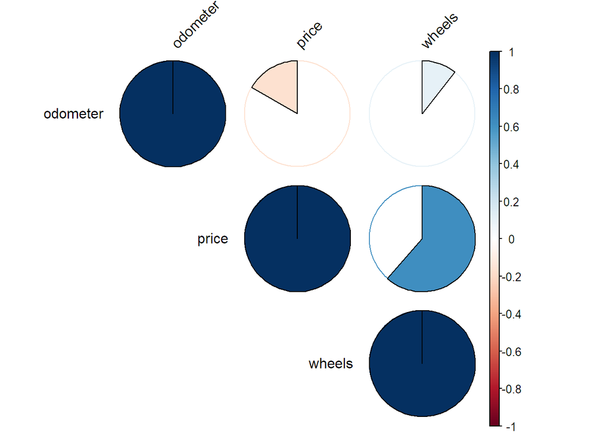

```r
# selecting numeric data
numeric_df <- select_if(data, is.numeric)

# creating correlation matrix
cor_matrix <- cor(numeric_df)

# ploting
corrplot(cor_matrix, method = "pie", type = "upper", order = "hclust",
         tl.col = "black", tl.srt = 45, addgrid.col = NA)
```

## Data Splitting and Cross-Validation

#### Data splitting

```r
# Splitting the data set into training 75% and testing 25% sets
split <- initial_split(data, prop = 0.75)

# Extracting the training and testing sets
train_data <- training(split)
test_data <- testing(split)
```

#### Creating Recipe

```r
tesla_recipe <- recipe(price ~ ., data = data) %>%
  step_dummy(all_nominal(), -all_outcomes()) %>%
  step_center(all_predictors()) %>%
  step_scale(all_predictors())
```

#### K-Fold Cross-Validatian

```r
# Create 10-fold cross-validation data splits
cv_splits <- vfold_cv(train_data, v = 10, strata = price)
```

## Model Fitting

- Now it is time to fit all the models!!!

#### Set up model specifications

```r
# Linear Regression
lm_spec <- linear_reg() %>%
  set_engine("lm") %>%
  set_mode("regression")

# Pruned Decision Tree
pruned_tree_spec <- decision_tree(cost_complexity = tune()) %>%
  set_engine("rpart") %>%
  set_mode("regression")

# Random Forest
rf_spec <- rand_forest(mtry = tune(), trees = 1000, min_n = tune()) %>%
  set_engine("ranger") %>%
  set_mode("regression")

# Elastic Net
elastic_spec <- linear_reg(penalty = tune(), mixture = tune()) %>%
  set_engine("glmnet") %>%
  set_mode("regression")

# K-Nearest Neighbors
knn_spec <- nearest_neighbor(neighbors = tune()) %>%
  set_engine("kknn") %>%
  set_mode("regression")
```

#### Set up workflow

```r
# Linear Regression Workflow
lm_workflow <- workflow() %>%
  add_recipe(tesla_recipe) %>%
  add_model(lm_spec)

# Pruned Decision Tree Workflow
pruned_tree_workflow <- workflow() %>%
  add_recipe(tesla_recipe) %>%
  add_model(pruned_tree_spec)

# Random Forest Workflow
rf_workflow <- workflow() %>%
  add_recipe(tesla_recipe) %>%
  add_model(rf_spec)

# Elastic Net Workflow
elastic_workflow <- workflow() %>%
  add_recipe(tesla_recipe) %>%
  add_model(elastic_spec)

# K-Nearest Neighbors Workflow
knn_workflow <- workflow() %>%
  add_recipe(tesla_recipe) %>%
  add_model(knn_spec)
```

#### Define the ranges for the tuning parameters for each model

```r
# Grid for Pruned Decision Tree
pruned_tree_grid <- grid_regular(cost_complexity(range = c(-10, -1)), levels = 10)

# Grid for Random Forest
rf_mtry <- mtry(range = c(1, 3))
rf_min_n <- min_n(range = c(1, 10))
rf_grid <- grid_regular(rf_mtry, rf_min_n, levels = 5)

# Grid for Elastic Net
elastic_grid <- grid_regular(
  penalty(range = c(-5, 3), trans = exp_trans()),
  mixture(c(0, 1)),
  levels = 10
)

# Grid for k-NN
knn_grid <- grid_regular(
  neighbors(range = c(1, 21)),
  levels = 10
)
```

#### Tune the models

```r
# No need to tune linear regression

# Tune the Pruned Decision Tree
pruned_tree_results <- tune_grid(
  pruned_tree_workflow,
  resamples = cv_splits,
  grid = pruned_tree_grid
)

# Tune the Random Forest
rf_results <- tune_grid(
  rf_workflow,
  resamples = cv_splits,
  grid = rf_grid
)

# Tune the Elastic Net
elastic_results <- tune_grid(
  elastic_workflow,
  resamples = cv_splits,
  grid = elastic_grid
)

# Tune the K-Nearest Neighbors
knn_results <- tune_grid(
  knn_workflow,
  resamples = cv_splits,
  grid = knn_grid
)
```

## Model Selection and Performance

- Now, Let’s check the model performance. To check the performance, we need to extract RMSE.
- The Root Mean Squared Error (RMSE) is one of the two main performance indicators for a regression model. It measures the average difference between values predicted by a model and the actual values. It provides an estimation of how well the model is able to predict the target value (accuracy). A lower RMSE means the model’s predictions are closer to the actual prices.

#### Extract and select best RMSE from the tuning results.

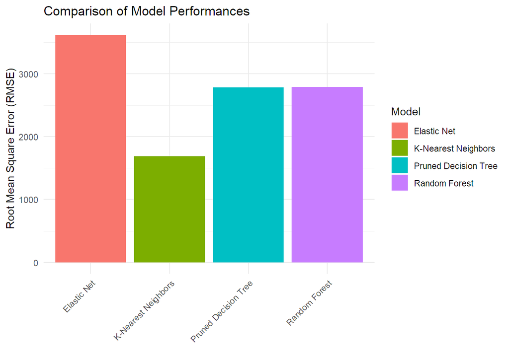

```r
# Extract RMSE for all models
pruned_tree_rmse <- collect_metrics(pruned_tree_results) %>%
  filter(.metric == "rmse") %>%
  summarize(mean_rmse = min(mean))

rf_rmse <- collect_metrics(rf_results) %>%
  filter(.metric == "rmse") %>%
  summarize(mean_rmse = min(mean))

elastic_rmse <- collect_metrics(elastic_results) %>%
  filter(.metric == "rmse") %>%
  summarize(mean_rmse = min(mean))

knn_rmse <- collect_metrics(knn_results) %>%
  filter(.metric == "rmse") %>%
  summarize(mean_rmse = min(mean))

# Create a summary table
performance_summary <- tibble(
  Model = c("Pruned Decision Tree", "Random Forest", "Elastic Net", "K-Nearest Neighbors"),
  RMSE = c(pruned_tree_rmse$mean_rmse, rf_rmse$mean_rmse, elastic_rmse$mean_rmse, knn_rmse$mean_rmse)
)
# Create a bar plot to visually compare the model performances.
ggplot(performance_summary, aes(x = Model, y = RMSE, fill = Model)) +
  geom_bar(stat = "identity") +
  labs(title = "Comparison of Model Performances",
       y = "Root Mean Square Error (RMSE)",
       x = "") +
  theme_minimal() +
  theme(axis.text.x = element_text(angle = 45, hjust = 1))
```

- From the plot, we can see that the K-Nearest Neighbors model has the lowest RMSE, making it the most accurate among the four models for predicting the price of Tesla used cars in this case. The Elastic Net model has the highest RMSE, indicating its predictions are furthest from the actual prices.
- So lets see the actual rmse for KNN model.

```r
knn_rmse
```

```
## # A tibble: 1 × 1
##   mean_rmse
##       <dbl>
## 1     1688.
```

#### Extract the best hyperparameters and Test on testing data set

```r
# Extract the best hyperparameter
best_knn_params <- knn_results %>%
  select_best(metric = "rmse")

# Print the best hyperparameter
print(best_knn_params)
```

```
## # A tibble: 1 × 2
##   neighbors .config
##       <int> <chr>
## 1         1 Preprocessor1_Model01
```

- The best hyperparameter for KNN is 1. It may be very sensitive to traning set and may cause over fitting and high variance for testing data set.

```r
# Finalize the KNN model with the best hyperparameters
final_knn_spec <- nearest_neighbor(neighbors = 1) %>%
  set_engine("kknn") %>%
  set_mode("regression")

# Fit the finalized model to the full training data
final_knn_fit <- workflow() %>%
  add_model(final_knn_spec) %>%
  add_recipe(tesla_recipe) %>%
  fit(data = train_data)

# Use the final model to make predictions on the test data
test_predictions <- predict(final_knn_fit, new_data = test_data) %>%
  bind_cols(test_data)

# Display the first few rows of the test data with predictions
head(test_predictions)
```

```
## # A tibble: 6 × 11
##   .pred model odometer price drive_train das   accident_history paint_job wheels
##   <dbl> <chr>    <dbl> <dbl> <chr>       <chr> <chr>            <chr>      <dbl>
## 1 53300 Mode…    36438 53300 All-wheel … Auto… Previously Repa… Red           19
## 2 53300 Mode…    36438 53300 All-wheel … Auto… Previously Repa… Red           19
## 3 36100 Mode…    95696 36100 All-wheel … Enha… No Reported Acc… Silver        19
## 4 51500 Mode…    32523 38500 All-wheel … Auto… No Reported Acc… Silver        19
## 5 47200 Mode…    38966 42000 All-wheel … Auto… No Reported Acc… Black         19
## 6 50400 Mode…    66754 45000 All-wheel … Auto… Previously Repa… White         19
## # ℹ 2 more variables: interior <chr>, region <fct>
```

```r
# Calculate the rmse for the testing data set
rmse_result <- test_predictions %>%
  metrics(truth = price, estimate = .pred)

# Extract RMSE
rmse_value <- rmse_result %>%
  filter(.metric == "rmse")

# Display the RMSE
rmse_value
```

```
## # A tibble: 1 × 3
##   .metric .estimator .estimate
##   <chr>   <chr>          <dbl>
## 1 rmse    standard       1250.
```

## Conclusion

- The testing RMSE is 1249.659 and the training RMSE is 1688.387. I am really surprised since the hyper parameter is 1. I thought it will over fit the data. But it turns out performs really well. The testing RMSE is lower than training RMSE indicate that the model could be capturing the underlying trends in the data without over fitting.
- Now I just want to test my parents vehicle and see how much it worth.

```r
# Create the new data
new_vehicle <- tibble(
  'model' = 'Model 3',
  'odometer' = 80000,
  'drive_train' = "All-wheel drive",
  'das' = "Full Self-Driving Capability",
  'accident_history' = "No Reported Accidents/Damage",
  'paint_job' = "White",
  'wheels' = 19,
  'interior' = "Premium Interior (Black and White)",
  'region' = "west"
)

# Predict using the data
predictions <- predict(final_knn_fit, new_data = new_vehicle)
print(predictions)
```

```
## # A tibble: 1 × 1
##   .pred
##   <dbl>
## 1 38100
```

- This value is much higher than the market price. But It’s ok.
- Thanks for reading!